# lab2

Oladele A. OLUWAYIOSE

2/2/2020

Exercise 1

```r
a <- c(1,3,6,9,12)
b<- c(1,0,1,0,1)
sum1<- a+b
sum1
```

```
## [1]  2  3  7  9 13
```

```r
prdct1<- a*b
prdct1
```

```
## [1]  1  0  6  0 12
```

```r
quotnt1<- a/b
quotnt1
```

```
## [1]   1 Inf   6 Inf  12
```

Exercise 2

Create 3 different vectors from (0,1,2,3), (“aa”,“bb”,“cc”,“dd”) and (“aa”,1,“bb”,2). Use str() to determine what data types each vector holds.

```r
x<- c(0,1,2,3)
y<- c("aa","bb","cc","dd")
z<- c("aa", 1, "bb", 2)
str(x)
```

```
##  num [1:4] 0 1 2 3
```

```r
str(y)
```

```
##  chr [1:4] "aa" "bb" "cc" "dd"
```

```r
str(z)
```

```
##  chr [1:4] "aa" "1" "bb" "2"
```

Exercise 3

```r
genotype1<- c("AA", "AA", "AG", "GG", "GG")
genotype2<- c("AA", "AA", "GG","GG", "GG")
matrx<- cbind(genotype1, genotype2)
class(matrx)
```

```
## [1] "matrix"
```

Exercise 4

Create a dataframe of the following experiment in samples were collected every 2 minutes starting at t = 0. treatment 1 (0,1,2,3,4), treatment 2 (0,2,4,6,8), treatment 3 (0,3,6,9,12). Display the dataframe. Plot treatment 3 vs. time (you will need to load time as a column rather than a row name)

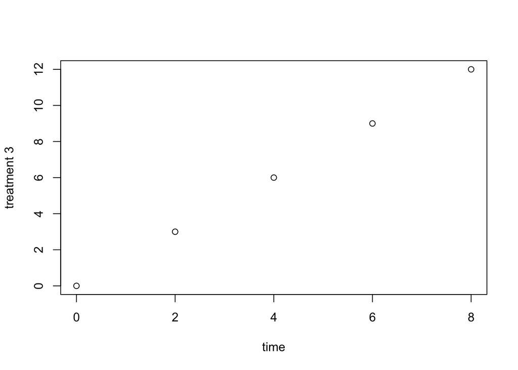

```r
trtmnt1<- c(0,1,2,3,4)
trtmnt2<- c(0,2,4,6,8)
trtmnt3<- c(0,3,6,9,12)
time<- c(0, 2, 4, 6, 8)
total<- data.frame(trtmnt1, trtmnt2, trtmnt3, time)
plot(total$time, total$trtmnt3, xlab = "time", ylab = "treatment 3")
```

Exercise 5

Following the example above with the truncated file use read.table to import the full SNP file 23andME_complete.txt. (This is a large file and may take several minutes to load into R).

What object type is chromosome? Why is it different from the above SNP_table example with the truncated file?

```r
SNP_table <- read.table("23andMe_complete.txt", header = TRUE, sep = "\t")
head(SNP_table)
```

```
##         rsid chromosome position genotype
## 1  rs4477212          1    82154       AA
## 2  rs3094315          1   752566       AA
## 3  rs3131972          1   752721       GG
## 4 rs12124819          1   776546       AG
## 5 rs11240777          1   798959       AG
## 6  rs6681049          1   800007       CC
```

```r
tail(SNP_table)
```

```
##            rsid chromosome position genotype
## 960609 i4000693         MT    16524        A
## 960610 i4000757         MT    16526        G
## 960611 i4990307         MT    16527        C
## 960612 i4000756         MT    16540        C
## 960613 i4000755         MT    16548        C
## 960614 i4000759         MT    16567        A
```

```r
str(SNP_table)
```

```
## 'data.frame':    960614 obs. of  4 variables:
##  $ rsid      : Factor w/ 960614 levels "i1000009","i2000003",..: 600125 532383 535928 178265 124446 723988 655510 600036 813048 254468 ...
##  $ chromosome: Factor w/ 25 levels "1","10","11",..: 1 1 1 1 1 1 1 1 1 1 ...
##  $ position  : int  82154 752566 752721 776546 798959 800007 838555 846808 854250 861808 ...
##  $ genotype  : Factor w/ 20 levels "--","A","AA",..: 3 3 15 5 5 8 4 10 5 15 ...
```

```r
class(SNP_table$chromosome) ##Object Chromosome in the complete table is a "factor"
```

```
## [1] "factor"
```

```r
SNP_table_trunc <- read.table("23andMe_example_cat25.txt", header = TRUE, sep = "\t")
str(SNP_table_trunc)
```

```
## 'data.frame':    10 obs. of  4 variables:
##  $ rsid      : Factor w/ 10 levels "rs11240777","rs12124819",..: 7 4 5 2 1 9 8 6 10 3
##  $ chromosome: int  1 1 1 1 1 1 1 1 1 1
##  $ position  : int  82154 752566 752721 776546 798959 800007 838555 846808 854250 861808
##  $ genotype  : Factor w/ 6 levels "AA","AC","AG",..: 1 1 6 3 3 4 2 5 3 6
```

```r
class(SNP_table_trunc$chromosome) ##Object chromosome in the trucated table is an "integer"
```

```
## [1] "integer"
```

Exercise 6

Make a table with the total number of each genotype. There may be unsual genotypes. 23andMe reports a very small number of deletions and insertions coded as D DD DI I II. The double dash – represents an uncertain (not reported) call at this position.

```r
genotype_freq <- table(SNP_table$genotype)
genotype_freq
```

```
##
##     --      A     AA     AC     AG     AT      C     CC     CG     CT
##  21109   6676 147157  25036 109001    569   7188 173264   1003 108992
##      D     DD     DI      G     GG     GT      I     II      T     TT
##     36    157     17   7061 173054  24727    113    685   6643 148126
```

Exercise 7

Determine which chromosome(s) the single letter genotype A is found on (e.g which chromosomes have only one copy of DNA)? Hint: Use subset() to make a table with just the genotype A.

```r
chrA<- subset(SNP_table, genotype=="A")
table(chrA$chromosome)
```

```
##
##    1   10   11   12   13   14   15   16   17   18   19    2   20   21   22
##    0    0    0    0    0    0    0    0    0    0    0    0    0    0    0
##    3    4    5    6    7    8    9   MT    X    Y
##    0    0    0    0    0    0    0  732 5782  162
```

```r
#Chromosomes with just single letter genotype: MT (732), X (5,782) and Y (162)
```